# Homework4

```r
library(MPV)
library(car)
```

## Question 1

1.1The chemical data is available as table.b5 in MPV package. We read that first. Then fit a MLR model by regressing CO2 product (y) on total solvent (x6) and hydrogen consumption (x7). The equation of the fitted regression line is given by $\hat{y} = 2.5265 + 0.0185 x6 + 2.1857 x7$.

```r
data("table.b5")
dat=table.b5
View(dat)
dat <- dat[,c(1,7,8)]
## Fit MLR model
mlr <- lm(y ~ x6+x7 , data=dat)
summary(mlr)
```

```
##
## Call:
## lm(formula = y ~ x6 + x7, data = dat)
##
## Residuals:
##      Min       1Q   Median       3Q      Max
## -23.2035  -4.3713   0.2513   4.9339  21.9682
##
## Coefficients:
##             Estimate Std. Error t value Pr(>|t|)
## (Intercept) 2.526460   3.610055   0.700   0.4908
## x6          0.018522   0.002747   6.742 5.66e-07 ***
## x7          2.185753   0.972696   2.247   0.0341 *
## ---
## Signif. codes:  0 '***' 0.001 '**' 0.01 '*' 0.05 '.' 0.1 ' ' 1
##
## Residual standard error: 9.924 on 24 degrees of freedom
## Multiple R-squared:  0.6996, Adjusted R-squared:  0.6746
## F-statistic: 27.95 on 2 and 24 DF,  p-value: 5.391e-07
```

1.2The assumptions for linear regression are the following:

(a)The relationship between response y and the regressors is linear, at least approximately.

(b)The random error term has zero mean and constant variance.

(c)The errors are uncorrelated.

(d)The errors are normally distributed.

1.3The following code constructs scatter plots for response variable vs. the regressors. We note that the plot or y vs. x6 shows a clear linear trend. The y vs. x7 is not as good as the other one, but an approximate linear trend can be observed in this plot as well.

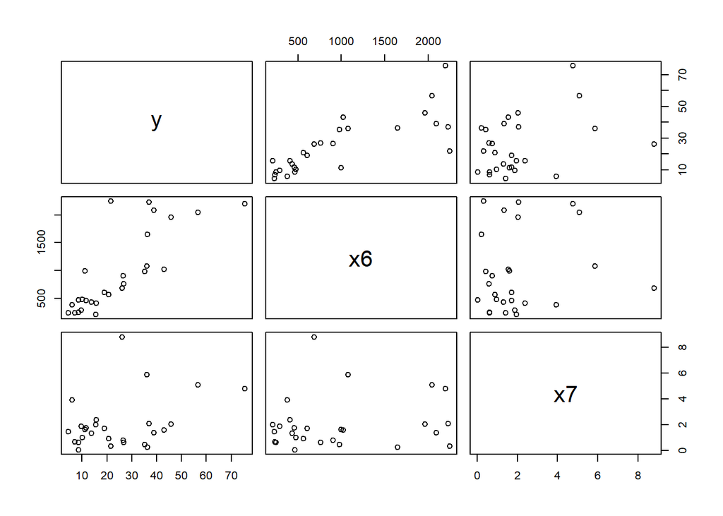

```r
pairs(dat)
```

1.4The regressor vs. residual plot can help us to check the linearity assumption. The plot is created below. As we scan such plots from left to right by considering thin vertical stripes and notice that in each stripe the vertical average of the residuals is approximately zero, we conclude that the linearity assumption is validated in both plots.

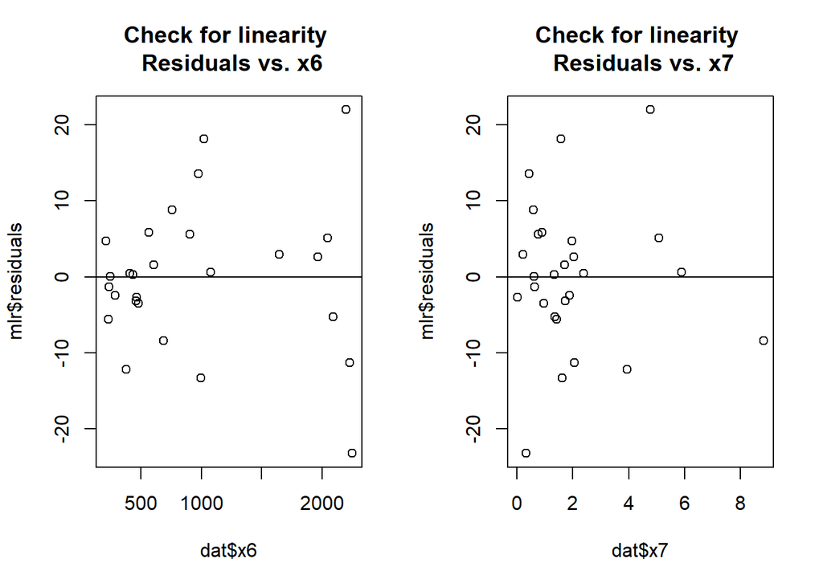

```r
par(mfcol = c(1, 2))
plot(dat$x6, mlr$residuals,
     main = "Check for linearity \n Residuals vs. x6")
abline(h=0)
plot(dat$x7, mlr$residuals,
     main = "Check for linearity \n Residuals vs. x7")
abline(h=0)
```

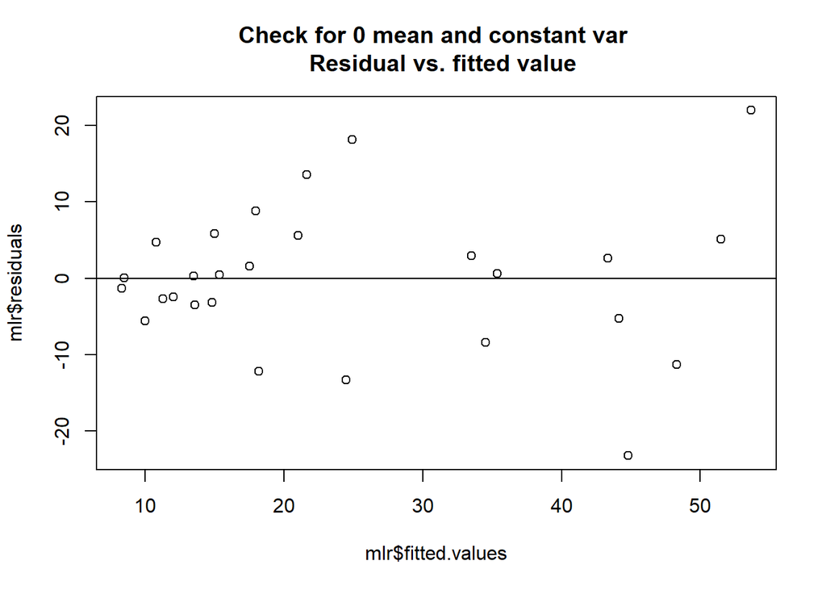

```r
plot(mlr$fitted.values, mlr$residuals,
     main = "Check for 0 mean and constant var \n  Residual vs. fitted value")
abline(h=0)
```

1.6The residual errors plotted against the row numbers sorted by regressor variables can help us to check the independence of error assumption. The plot is created below. As we scan such plots from left to right by considering thin vertical stripes we notice that randomly and symmetrically distributed around zero. Hence we conclude that the independence of error assumption is validated by both plots.

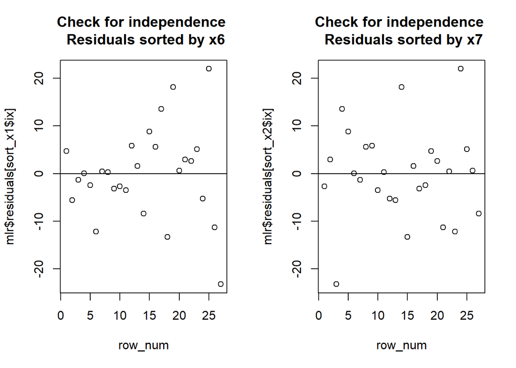

```r
par(mfcol = c(1, 2))
row_num <- c(1:nrow(dat))
sort_x1 <- sort(dat$x6, index.return=TRUE)
plot(row_num, mlr$residuals[sort_x1$ix],
     main = "Check for independence \n Residuals sorted by x6")
abline(h=0)
sort_x2 <- sort(dat$x7, index.return=TRUE)
plot(row_num, mlr$residuals[sort_x2$ix],
     main = "Check for independence \n Residuals sorted by x7")
abline(h=0)
```

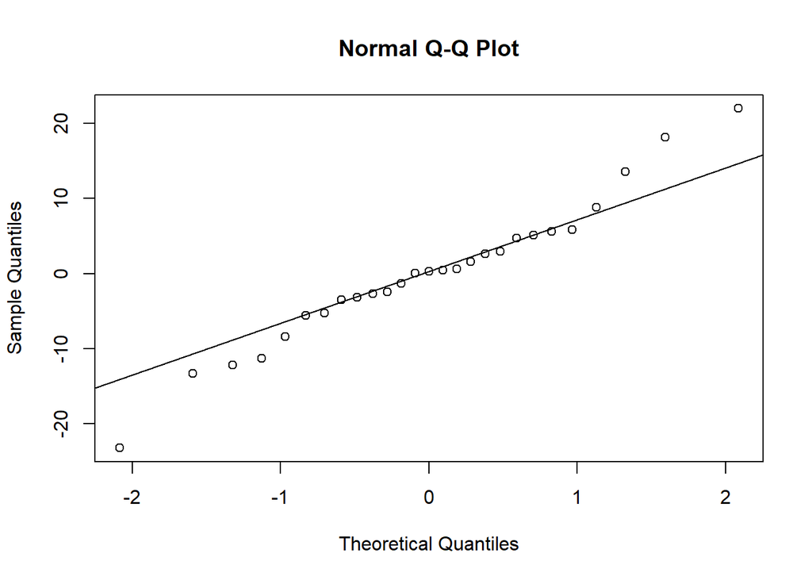

```r
qqnorm(mlr$residuals)
qqline(mlr$residuals)
```

1.8The Shapiro-Wilk test can also be performed to check the normality assumption of error terms. The test is performed below. Here the null hypothesis is error terms follow normal distribution. Based on the p-value (greater than $\alpha = 0.05$) we conclude that we fail to reject the null hypothesis and hence it is likely that error terms follow normal distribution.

```r
shapiro.test(mlr$residuals)
```

```
##
##  Shapiro-Wilk normality test
##
## data:  mlr$residuals
## W = 0.97358, p-value = 0.6981
```

## Question 2

2.1We consider the windmill data as follows. First we fit a SLR model by regressing DC output (y) on wind velocity (x). The equation of the fitted regression line is given by $\hat{y} = 0.1309 + 0.2411 x$.

```r
x <- c(5,   6,  3.4,    2.7,    10, 9.7,    9.55,   3.05,   8.15,   6.2,    2.9,    6.35,   4.6,    5.8,    7.4,    3.6,    7.85,   8.8,    7,  5.45,   9.1,    10.2,   4.1,    3.95,   2.45)
y <- c(1.582,   1.822,  1.057,  0.5,    2.236,  2.386,  2.294,  0.558,  2.166,  1.866,  0.653,  1.93,   1.562,  1.737,  2.088,  1.137,  2.179,  2.112,  1.8,    1.501,  2.303,  2.31,   1.194,  1.144,  0.123)
dat <- data.frame(x, y)
View(dat)

## Fit SLR model
slr <- lm(y ~ x , data=dat)
summary(slr)
```

```
##
## Call:
## lm(formula = y ~ x, data = dat)
##
## Residuals:
##      Min       1Q   Median       3Q      Max
## -0.59869 -0.14099  0.06059  0.17262  0.32184
##
## Coefficients:
##             Estimate Std. Error t value Pr(>|t|)
## (Intercept)  0.13088    0.12599   1.039     0.31
## x            0.24115    0.01905  12.659 7.55e-12 ***
## ---
## Signif. codes:  0 '***' 0.001 '**' 0.01 '*' 0.05 '.' 0.1 ' ' 1
##
## Residual standard error: 0.2361 on 23 degrees of freedom
## Multiple R-squared:  0.8745, Adjusted R-squared:  0.869
## F-statistic: 160.3 on 1 and 23 DF,  p-value: 7.546e-12
```

1.2The assumptions for linear regression are the following:

(a)The relationship between response y and the regressors is linear, at least approximately.

(b)The random error term has zero mean and constant variance.

(c)The errors are uncorrelated.

(d)The errors are normally distributed.

2.3The following code constructs scatter plot for response variable vs. the regressors. We note that the plot or y vs. x shows a curvilinear trend.

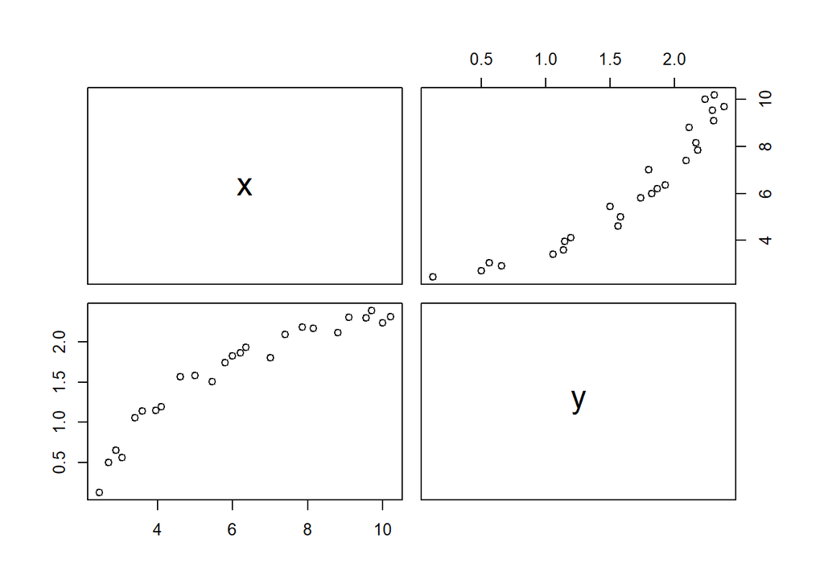

```r
pairs(dat)
```

The regressor vs. residual plot can help us to check the linearity assumption. The plot is created below. As we scan the plot from left to right by considering thin vertical stripes we notice that the vertical average of the residuals is negative at both edges and positive in the middle. Hence we conclude that the linearity assumption is violated.

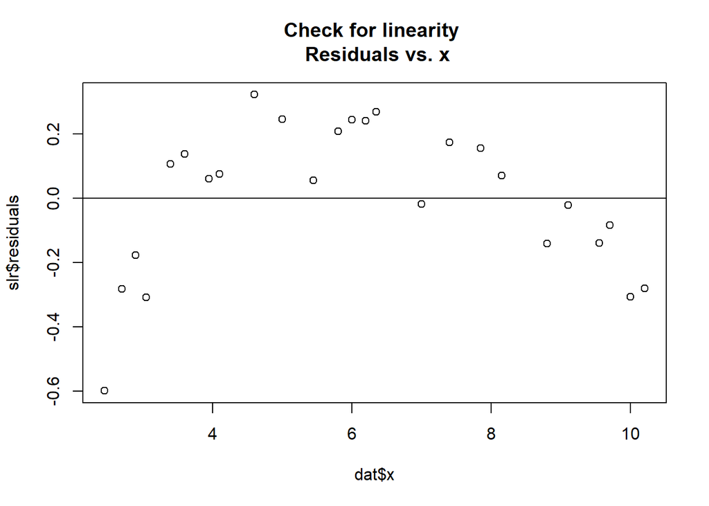

```r
plot(dat$x, slr$residuals,
     main = "Check for linearity \n Residuals vs. x")
abline(h=0)
```

The residual errors against the fitted values can help us to check the zero mean and constant variance assumption. The plot is created below. In this plot as well, as we scan the plot from left to right by considering thin vertical stripes we notice that the vertical average of the residuals is negative at both edges and positive in the middle. Hence we conclude that the assumption of zero mean is not satisfied. The spread of the data points however is approximately the same in all vertical stripes. Thus constant variance is most likely satisfied.

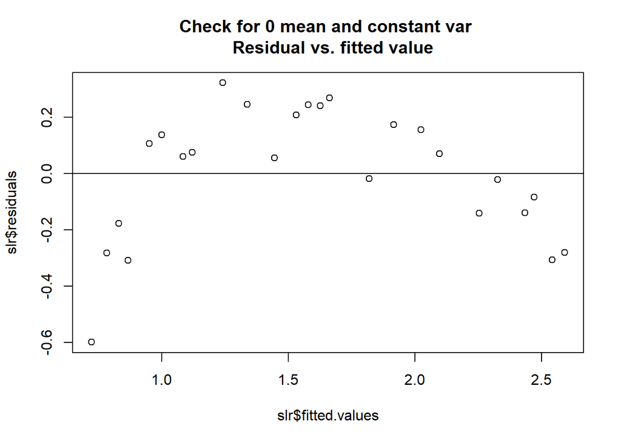

```r
plot(slr$fitted.values, slr$residuals,
     main = "Check for 0 mean and constant var \n  Residual vs. fitted value")
abline(h=0)
```

The residual errors plotted against the row numbers sorted by regressor variables can help us to check the independence of error assumption. The plot is created below. As we scan the plot from left to right by considering thin vertical stripes we notice that the vertical average of the residuals is negative at both edges and positive in the middle. Hence we conclude that the independence of error assumption is violated here.

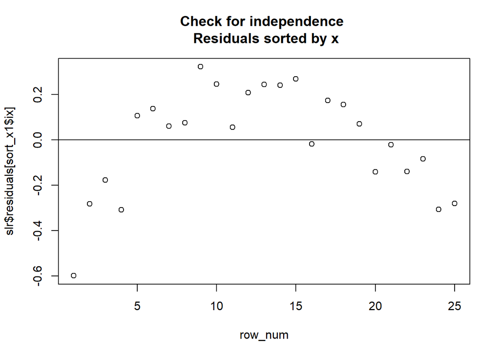

```r
row_num <- c(1:nrow(dat))
sort_x1 <- sort(dat$x, index.return=TRUE)
plot(row_num, slr$residuals[sort_x1$ix],
     main = "Check for independence \n Residuals sorted by x")
abline(h=0)
```

The normal q-q plot can help us to check the assumption that error terms follow a normal distribution. The plot is created below. The normal q-q plot suggests that the error terms follow a negatively skewed distribution which is a violation from normality.

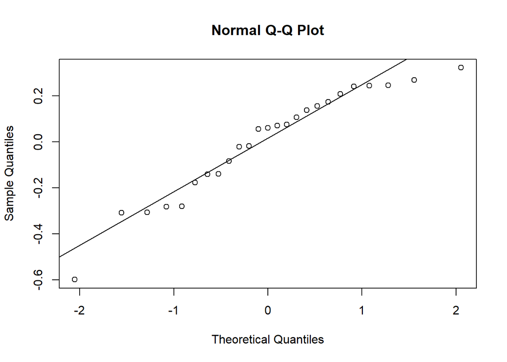

```r
qqnorm(slr$residuals)
qqline(slr$residuals)
```

2.4In order to improve the model we apply a square transformation to the response variable and create a new variable called y_tran. From the pairs() plot we note that the scatter plot of x vs. y_tran is approximately linear. The curvilinear nature of the scatter plot between x vs. y prompted us to try this transformation.

Then we fit a SLR model by regressing y_tran on x. The new model has a improved adjusted $R^2$ of 0.9532.

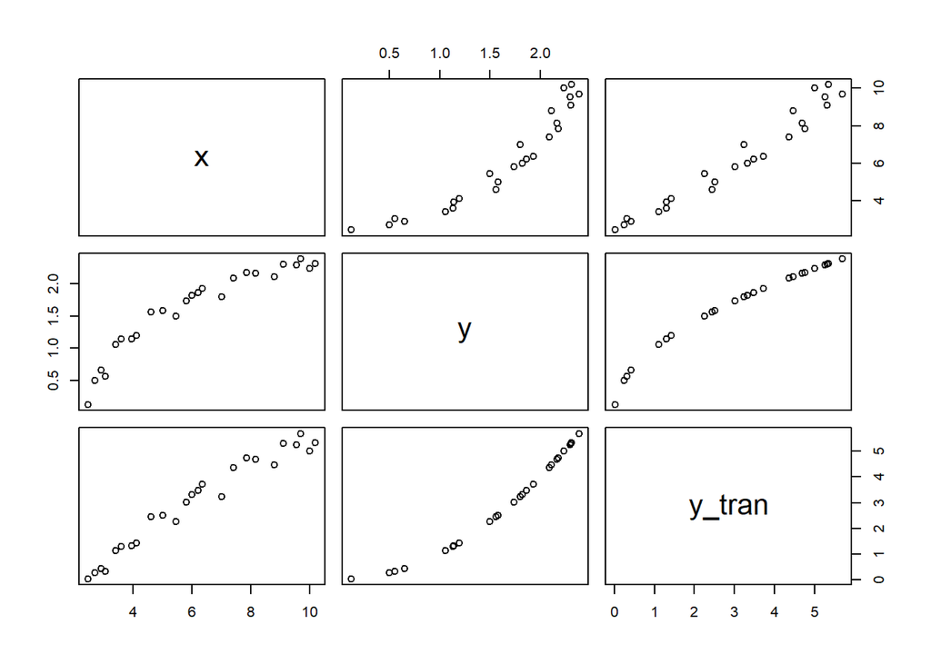

```r
dat$y_tran <- (dat$y)^2
pairs(dat)
```

```r
## Fit SLR model with transformed variable
slr2 <- lm(y_tran ~ x , data=dat)
summary(slr2)
```

```
##
## Call:
## lm(formula = y_tran ~ x, data = dat)
##
## Residuals:
##      Min       1Q   Median       3Q      Max
## -0.74840 -0.31027  0.05951  0.30793  0.57072
##
## Coefficients:
##             Estimate Std. Error t value Pr(>|t|)
## (Intercept) -1.35851    0.21239  -6.396 1.58e-06 ***
## x            0.71066    0.03211  22.130  < 2e-16 ***
## ---
## Signif. codes:  0 '***' 0.001 '**' 0.01 '*' 0.05 '.' 0.1 ' ' 1
##
## Residual standard error: 0.3979 on 23 degrees of freedom
## Multiple R-squared:  0.9551, Adjusted R-squared:  0.9532
## F-statistic: 489.7 on 1 and 23 DF,  p-value: < 2.2e-16
```

2.5Then we create the residual plots again based on the new “slr2” model. The residual plots obtained here are, although not perfect, yet much better than the ones obtained before.

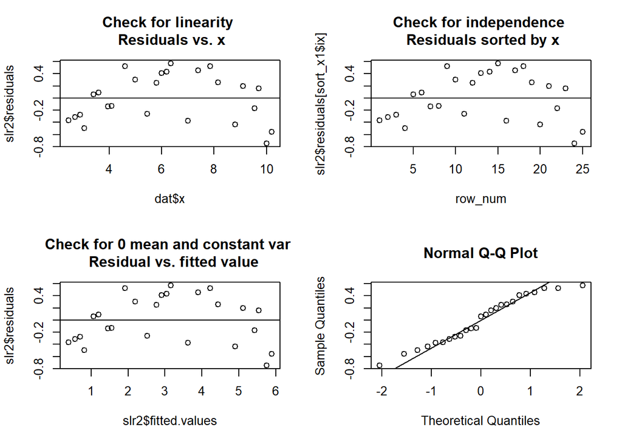

```r
par(mfcol = c(2, 2))
plot(dat$x, slr2$residuals,
     main = "Check for linearity \n Residuals vs. x")
abline(h=0)

plot(slr2$fitted.values, slr2$residuals,
     main = "Check for 0 mean and constant var \n  Residual vs. fitted value")
abline(h=0)

row_num <- c(1:nrow(dat))
sort_x1 <- sort(dat$x, index.return=TRUE)
plot(row_num, slr2$residuals[sort_x1$ix],
     main = "Check for independence \n Residuals sorted by x")
abline(h=0)

qqnorm(slr2$residuals)
qqline(slr2$residuals)
```

2.6Finally for estimating the mean DC output where wind_velocity = 5 mph, we will use the fitted regression line given by $\hat{ytran} = -1.3585 + 0.7107 x$. Substituting $x=5$ in this equation we get $ytran = 2.195$. Now recall, $ytran = y^2$. Hence $y = sqrt(2.195) = 1.4815$. Thus the mean DC output where wind_velocity = 5 mph is 1.4815.

Note that, the this problem can also be solved by using the predict function as below. Here we do not need the interval, so we don’t worry whether we are using prediction or confidence interval.

```r
## Confidence interval for mean y_tran for a given value of x=5
newDat <- data.frame(x=5)
predict(slr2, newdata = newDat, interval = 'confidence', level = 0.95)
```

```
##        fit      lwr      upr
## 1 2.194792 2.013792 2.375791
```

```r
## Confidence interval for mean y for a given value of x=5
sqrt(predict(slr2, newdata = newDat, interval = 'confidence', level = 0.95))
```

```
##        fit      lwr     upr
## 1 1.481483 1.419082 1.54136
```

## Another transformation approach for Question 2

Instead of applying a transformation to the response variable, we can also try to transform x. Here we try an inverse transformation for x by creating a new variable called x_tran. From the pairs() plot we note that the scatter plot of x_tran vs. y is approximately linear. The transformation guide prompted us to try this transformation.

Then we fit a SLR model by regressing y on x_tran. The adjusted $R^2$ (0.9792) of this model is even better than “slr2”. We see that there exists multiple good transformations.

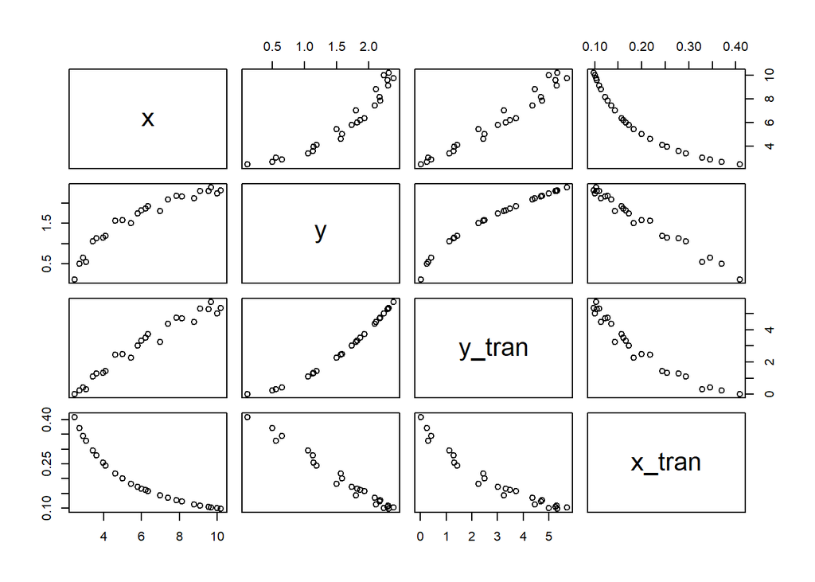

```r
dat$x_tran <- 1/(dat$x)
pairs(dat)
```

```r
## Fit SLR model with transformed variable
slr3 <- lm(y ~ x_tran , data=dat)
summary(slr3)
```

```
##
## Call:
## lm(formula = y ~ x_tran, data = dat)
##
## Residuals:
##      Min       1Q   Median       3Q      Max
## -0.20547 -0.04940  0.01100  0.08352  0.12204
##
## Coefficients:
##             Estimate Std. Error t value Pr(>|t|)
## (Intercept)   2.9789     0.0449   66.34   <2e-16 ***
## x_tran       -6.9345     0.2064  -33.59   <2e-16 ***
## ---
## Signif. codes:  0 '***' 0.001 '**' 0.01 '*' 0.05 '.' 0.1 ' ' 1
##
## Residual standard error: 0.09417 on 23 degrees of freedom
## Multiple R-squared:   0.98,  Adjusted R-squared:  0.9792
## F-statistic:  1128 on 1 and 23 DF,  p-value: < 2.2e-16
```

The model assumptions can be verified by creating residual plots and normal q-q plots as below. Residual plots are satisfactory. Normal q-q plot suggests data is negatively skewed.

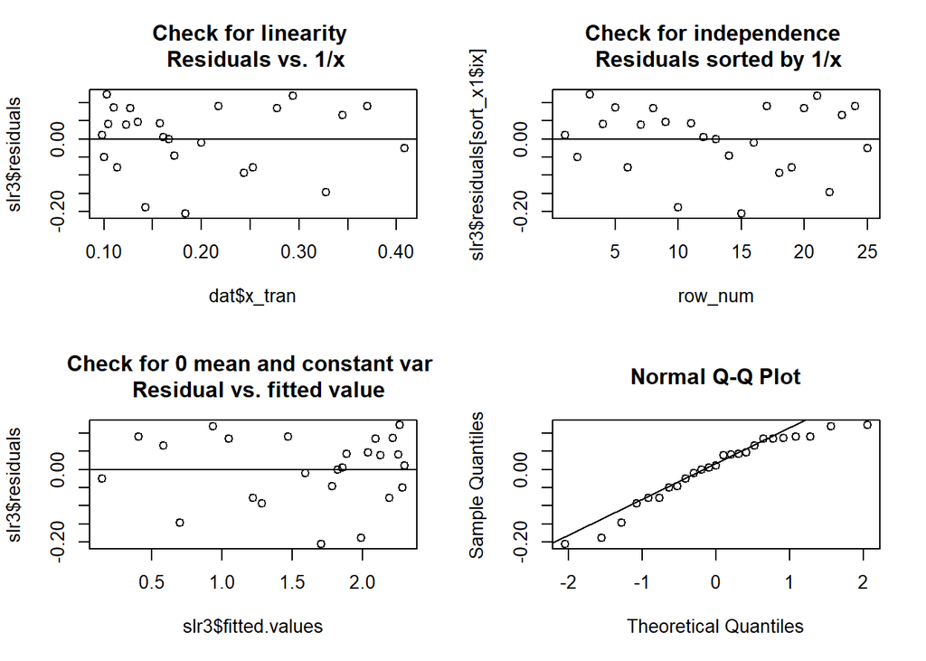

```r
par(mfcol = c(2, 2))
plot(dat$x_tran, slr3$residuals,
     main = "Check for linearity \n Residuals vs. 1/x")
abline(h=0)

plot(slr3$fitted.values, slr3$residuals,
     main = "Check for 0 mean and constant var \n  Residual vs. fitted value")
abline(h=0)

row_num <- c(1:nrow(dat))
sort_x1 <- sort(dat$x_tran, index.return=TRUE)
plot(row_num, slr3$residuals[sort_x1$ix],
     main = "Check for independence \n Residuals sorted by 1/x")
abline(h=0)

qqnorm(slr3$residuals)
qqline(slr3$residuals)
```

Let us know see, how to answer Q2.6 using this model. The fitted regression equation is $\hat{y} = 2.9789 - 6.9345 xtran$. But recall, $xtran = 1/x$. Hence we have, $\hat{y} = 2.9789 - 6.9345 \times (1/x)$. Substituting $x=5$ in this equation we get $\hat{y} = 2.9789 - 6.9345 \times (1/5) = 1.592$. Thus the mean DC output where wind_velocity = 5 mph is 1.592 using this model. Note that, this estimate is slightly different from the one obtained from “slr2” model.

If we want to use the predict() function to get this estimate we use the following code. Notice that, in this case we created the newDat data frame with x_tran = 1/5.

```r
## Confidence interval for mean y for a given value of x=5 i.e. 1/x = 1/5
newDat <- data.frame(x_tran=1/5)
predict(slr3, newdata = newDat, interval = 'confidence', level = 0.95)
```

```
##        fit      lwr      upr
## 1 1.591951 1.552974 1.630928
```